# anexo_seleccion

2023-02-03

# Anexos

## Otros metodos de seleccion de variables

Como un complemento a la selección de variables de tipo **Stepwise** que se ha estudiado en el apartado de selección de variables se ha decidido estudiar otras alternativas de selección de features utilizando diversas técnicas que se detallan a continuación:

### Utilizando la libreria party y random forest

Un método de selección de variables es utilizando el algoritmo de random forest para encontrar un set de predictores, para eso se utiliza la librería *party* y se obtienen los siguientes resultados:

```r
library(party)
s1 <- cforest(varObjBin ~ . ,
    data = dengue2,
    control = cforest_unbiased(mtry = 2, ntree = 50))
varimp(s1)
```

```
##       humid     humid90        temp      temp90      h10pix    h10pix90
## 0.019011819 0.024480176 0.007135328 0.010393915 0.044306715 0.036816130
##       trees     trees90        Xmin        Xmax        Ymin        Ymax
## 0.004198915 0.005095990 0.011027785 0.009075744 0.028311803 0.024437635
```

### Utilizando *MARS: Multivariate Adaptive Regression Splines*

Otro método de selección de variables es utilizando MARS, contenida en la librería *earth* para R

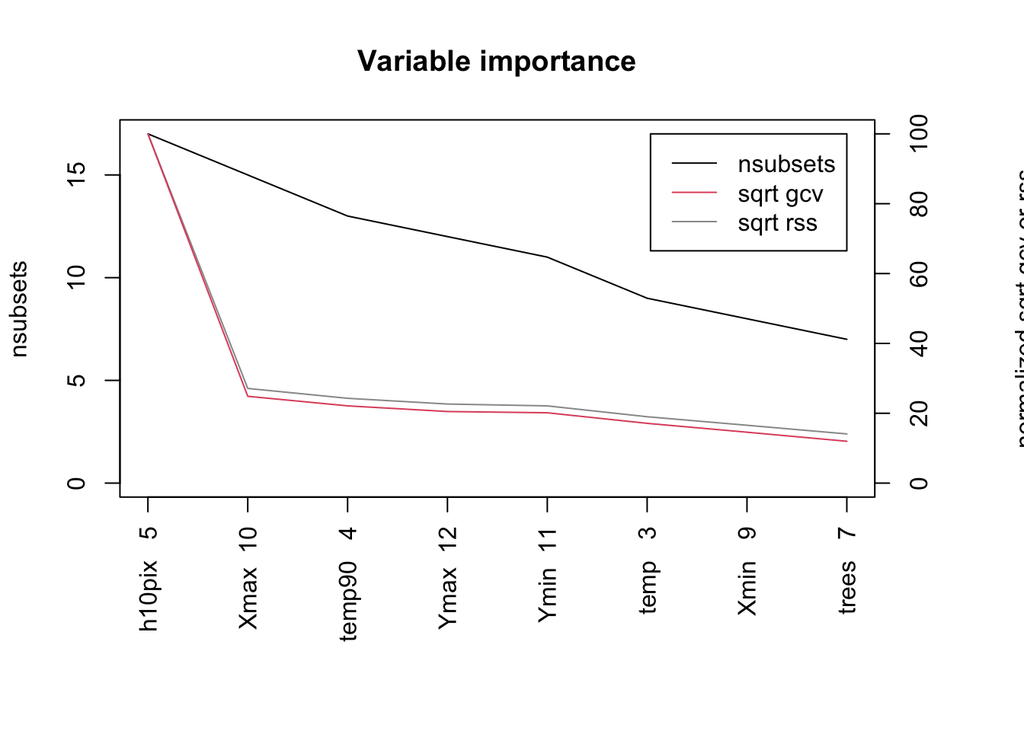

```r
library(earth)
s2 <- earth(varObjBin ~ ., data=dengue2) # build model
evaluacion <- evimp (s2)
plot(evaluacion)
```

### Utilizando la libreria Boruta

Boruta es otra librería para realizar *feature selection* de forma automática, permitiendo un acercamiento inicial rápido al dataset (con sus ventajas y desventajas):

```r
library(Boruta)
boruta_model <- Boruta(varObjBin ~ ., data= dengue2, doTrace=2)
relevancia <- names(boruta_model$finalDecision[boruta_model$finalDecision %in% c("Confirmed")])
print(relevancia)
```

```
##  [1] "humid"    "humid90"  "temp"     "temp90"   "h10pix"   "h10pix90"
##  [7] "trees"    "trees90"  "Xmin"     "Xmax"     "Ymin"     "Ymax"
```

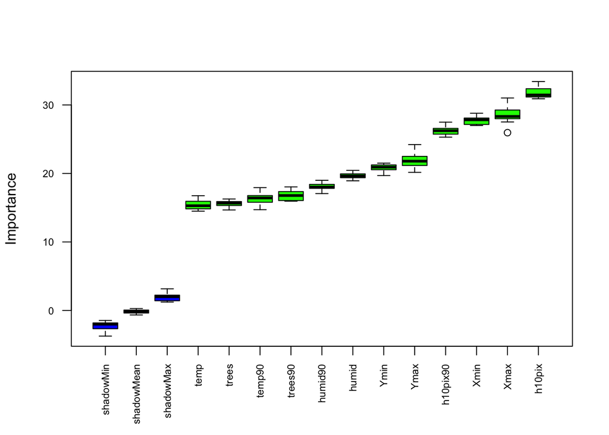

```r
plot(boruta_model, las = 2, cex.axis=0.7, xlab="")
```

Boruta permite revisar si el set de variables a estudiar entran en el modelo o podrían entrar de forma tentativa o definitivamente no han sido considerados como variables predictoras relevantes con lo cual también se pueden probar otros modelos y combinaciones (ej confirmados mas algún tentativo etc)

Para este dataset en particular la selección no marca variables como tentativas o descartadas por lo cual correspondería observar el gráfico generado y realizar algún corte de tipo manual en las variables.

### Utilizando RFE con caret

Eliminación recursiva de características o RFE en sus siglas en ingles, es un estimador que asigna pesos a las características del dataset que se quiere estudiar

```r
set.seed(7)
# Cargar datos
data(dengue2)
# Se define la funcion de control
controlrfe <- rfeControl(functions=rfFuncs, method="cv", number=4)
# Algoritmo RFE
res_rfe <- rfe(dengue2[,2:12], dengue2[,1], sizes=c(2:12), rfeControl=controlrfe)
#Resultados
print(res_rfe)
```

```
##
## Recursive feature selection
##
## Outer resampling method: Cross-Validated (4 fold)
##
## Resampling performance over subset size:
##
##  Variables   RMSE Rsquared     MAE   RMSESD RsquaredSD    MAESD Selected
##          2 0.2559   0.7144 0.13033 0.080328   0.188079 0.080015
##          3 0.2103   0.8186 0.09381 0.008193   0.013435 0.001988
##          4 0.2093   0.8200 0.09198 0.006153   0.011944 0.003804
##          5 0.1927   0.8479 0.08635 0.009504   0.014010 0.004464
##          6 0.1915   0.8499 0.08543 0.008331   0.011868 0.003713        *
##          7 0.1934   0.8473 0.08939 0.006407   0.009145 0.004466
##          8 0.1941   0.8465 0.09210 0.004874   0.007074 0.003773
##          9 0.1949   0.8450 0.09183 0.004130   0.007247 0.003856
##         10 0.1985   0.8395 0.09571 0.004161   0.006483 0.003471
##         11 0.2012   0.8353 0.09888 0.002943   0.007213 0.002814
##
## The top 5 variables (out of 6):
##    Xmax, h10pix, Xmin, h10pix90, Ymin
```

```r
# Features escogidas
predictors(res_rfe)
```

```
## [1] "Xmax"     "h10pix"   "Xmin"     "h10pix90" "Ymin"     "temp"
```

```r
# graficos
# plot(results, type=c("g", "o"))
```

```r
# Generado con libreria party
anexo1 <- cruzadalogistica(
    data = data,
    vardep = "varObjBin", listconti = c("humid", "humid90","temp", "temp90",
    "h10pix", "h10pix90"),
    listclass = c(""),
    grupos = 4, sinicio = 1234, repe = 5)

anexo1$modelo <- "log-party"


# Generado con MARS
anexo2 <- cruzadalogistica(
    data = data,
    vardep = "varObjBin",
    listconti = c("h10pix", "Xmax", "temp90", "Ymax", "Ymin", "temp", "Xmin",
                  "trees"),
    listclass = c(""),
    grupos = 4, sinicio = 1234, repe = 5)

anexo2$modelo <- "log-mars"

# Generado con Boruta
anexo3 <- cruzadalogistica(
    data = data,
    vardep = "varObjBin",
    listconti = c("h10pix", "Xmax", "Xmin", "h10pix90", "Ymax"),
    listclass = c(""),
    grupos = 4, sinicio = 1234, repe = 5)

anexo3$modelo <- "log-boruta"


# Generado con RFE
anexo4 <- cruzadalogistica(
    data = data,
    vardep = "varObjBin",
    listconti = c("Xmax", "h10pix","Xmin","h10pix90","Ymin","temp" ),
    listclass = c(""),
    grupos = 4, sinicio = 1234, repe = 5)

anexo4$modelo <- "log-RFE"
```